# d3-ease

*Easing* is a method of distorting time to control apparent motion in animation. It is most commonly used for [slow-in, slow-out](https://en.wikipedia.org/wiki/12_basic_principles_of_animation#Slow_In_and_Slow_Out). By easing time, animated transitions are smoother and exhibit more plausible motion.

The easing types in this module implement the ease method, which takes a normalized time *t* and returns the corresponding “eased” time *tʹ*. Both the normalized time and the eased time are typically in the range [0,1], where 0 represents the start of the animation and 1 represents the end; some easing types, such as elastic, may return eased times slightly outside this range. A good easing type should return 0 if *t* = 0 and 1 if *t* = 1. See the [easing explorer](https://observablehq.com/@d3/easing) for a visual demonstration.

These easing types are largely based on work by [Robert Penner](http://robertpenner.com/easing/).

## Installing

If you use npm, `npm install d3-ease`. You can also download the [latest release on GitHub](https://github.com/d3/d3-ease/releases/latest). For vanilla HTML in modern browsers, import d3-ease from Skypack:

```
<script type="module">

import {easeCubic} from "https://cdn.skypack.dev/d3-ease@3";

const e = easeCubic(0.25);

</script>
```

For legacy environments, you can load d3-ease’s UMD bundle from an npm-based CDN such as jsDelivr; a `d3` global is exported:

```
<script src="https://cdn.jsdelivr.net/npm/d3-ease@3"></script>
<script>

const e = d3.easeCubic(0.25);

</script>
```

[Try d3-ease in your browser.](https://observablehq.com/@d3/easing-animations)

## API Reference

###### *ease*(*t*)

Given the specified normalized time *t*, typically in the range [0,1], returns the “eased” time *tʹ*, also typically in [0,1]. 0 represents the start of the animation and 1 represents the end. A good implementation returns 0 if *t* = 0 and 1 if *t* = 1. See the [easing explorer](https://observablehq.com/@d3/easing) for a visual demonstration. For example, to apply cubic easing:

```
const te = d3.easeCubic(t);
```

Similarly, to apply custom elastic easing:

```
// Before the animation starts, create your easing function.
const customElastic = d3.easeElastic.period(0.4);

// During the animation, apply the easing function.
const te = customElastic(t);
```

###### d3.**easeLinear**(*t*) [Source](https://github.com/d3/d3-ease/blob/master/src/linear.js)

Linear easing; the identity function; *linear*(*t*) returns *t*.

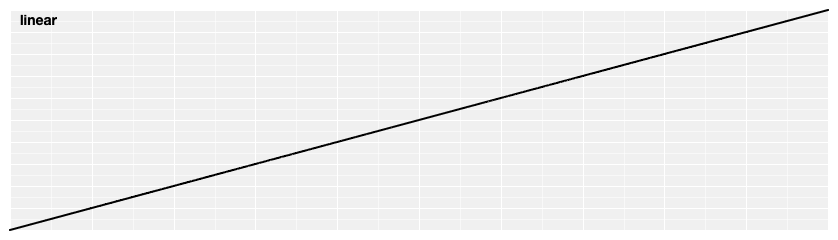

###### d3.**easePolyIn**(*t*) [Source](https://github.com/d3/d3-ease/blob/master/src/poly.js#L3)

Polynomial easing; raises *t* to the specified exponent. If the exponent is not specified, it defaults to 3, equivalent to cubicIn.

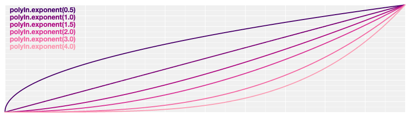

###### d3.**easePolyOut**(*t*) [Source](https://github.com/d3/d3-ease/blob/master/src/poly.js#L15)

Reverse polynomial easing; equivalent to 1 - polyIn(1 - *t*). If the exponent is not specified, it defaults to 3, equivalent to cubicOut.

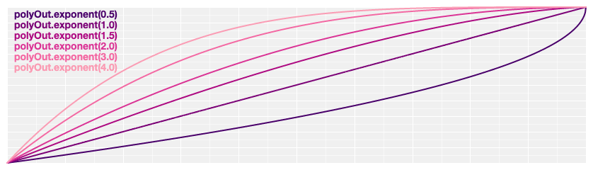

###### d3.**easePoly**(*t*) [Source](https://github.com/d3/d3-ease/blob/master/src/poly.js) d3.**easePolyInOut**(*t*) [Source](https://github.com/d3/d3-ease/blob/master/src/poly.js#L27)

Symmetric polynomial easing; scales polyIn for *t* in [0, 0.5] and polyOut for *t* in [0.5, 1]. If the exponent is not specified, it defaults to 3, equivalent to cubic.

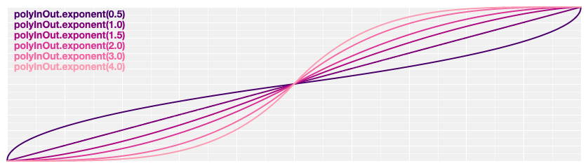

###### *poly*.**exponent**(*e*) [Source](https://github.com/d3/d3-ease/blob/master/src/poly.js#L1)

Returns a new polynomial easing with the specified exponent *e*. For example, to create equivalents of linear, quad, and cubic:

```
const linear = d3.easePoly.exponent(1);
const quad = d3.easePoly.exponent(2);
const cubic = d3.easePoly.exponent(3);
```

###### d3.**easeQuadIn**(*t*) [Source](https://github.com/d3/d3-ease/blob/master/src/quad.js#L1)

Quadratic easing; equivalent to polyIn.exponent(2).

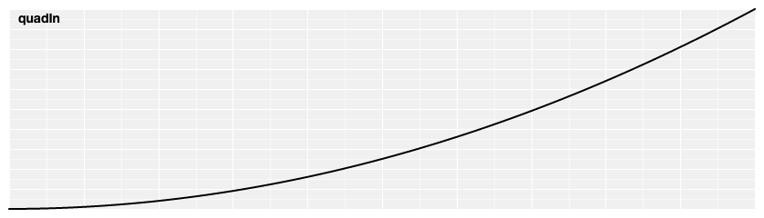

###### d3.**easeQuadOut**(*t*) [Source](https://github.com/d3/d3-ease/blob/master/src/quad.js#L5)

Reverse quadratic easing; equivalent to 1 - quadIn(1 - *t*). Also equivalent to polyOut.exponent(2).

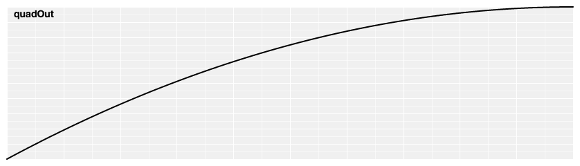

###### d3.**easeQuad**(*t*) [Source](https://github.com/d3/d3-ease/blob/master/src/quad.js) d3.**easeQuadInOut**(*t*) [Source](https://github.com/d3/d3-ease/blob/master/src/quad.js#L9)

Symmetric quadratic easing; scales quadIn for *t* in [0, 0.5] and quadOut for *t* in [0.5, 1]. Also equivalent to poly.exponent(2).

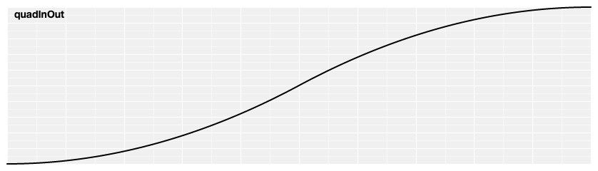

###### d3.**easeCubicIn**(*t*) [Source](https://github.com/d3/d3-ease/blob/master/src/cubic.js#L1)

Cubic easing; equivalent to polyIn.exponent(3).

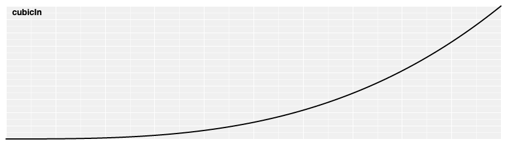

###### d3.**easeCubicOut**(*t*) [Source](https://github.com/d3/d3-ease/blob/master/src/cubic.js#L5)

Reverse cubic easing; equivalent to 1 - cubicIn(1 - *t*). Also equivalent to polyOut.exponent(3).

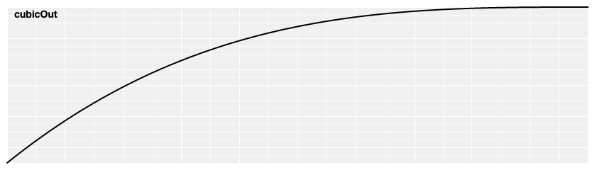

###### d3.**easeCubic**(*t*) [Source](https://github.com/d3/d3-ease/blob/master/src/cubic.js) d3.**easeCubicInOut**(*t*) [Source](https://github.com/d3/d3-ease/blob/master/src/cubic.js#L9)

Symmetric cubic easing; scales cubicIn for *t* in [0, 0.5] and cubicOut for *t* in [0.5, 1]. Also equivalent to poly.exponent(3).

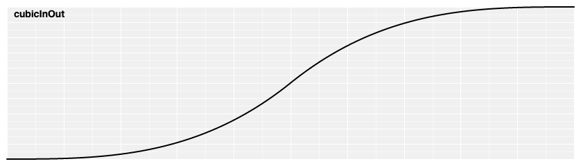

###### d3.**easeSinIn**(*t*) [Source](https://github.com/d3/d3-ease/blob/master/src/sin.js#L4)

Sinusoidal easing; returns sin(*t*).

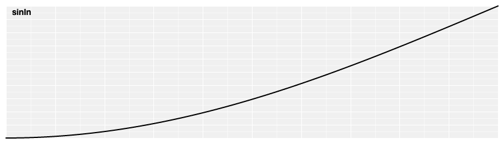

###### d3.**easeSinOut**(*t*) [Source](https://github.com/d3/d3-ease/blob/master/src/sin.js#L8)

Reverse sinusoidal easing; equivalent to 1 - sinIn(1 - *t*).

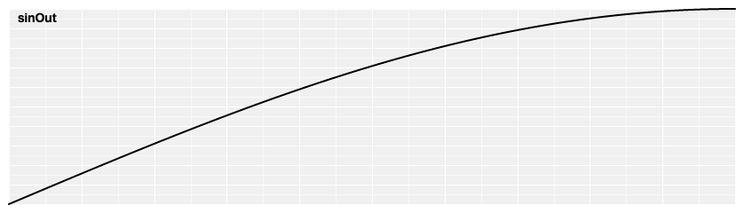

###### d3.**easeSin**(*t*) [Source](https://github.com/d3/d3-ease/blob/master/src/sin.js) d3.**easeSinInOut**(*t*) [Source](https://github.com/d3/d3-ease/blob/master/src/sin.js#L12)

Symmetric sinusoidal easing; scales sinIn for *t* in [0, 0.5] and sinOut for *t* in [0.5, 1].

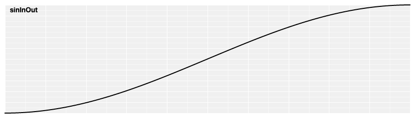

###### d3.**easeExpIn**(*t*) [Source](https://github.com/d3/d3-ease/blob/master/src/exp.js#L1)

Exponential easing; raises 2 to the exponent 10 * (*t* - 1).

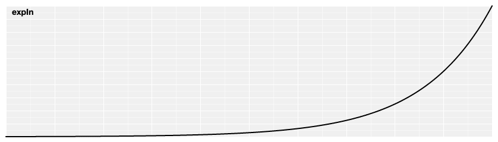

###### d3.**easeExpOut**(*t*) [Source](https://github.com/d3/d3-ease/blob/master/src/exp.js#L5)

Reverse exponential easing; equivalent to 1 - expIn(1 - *t*).

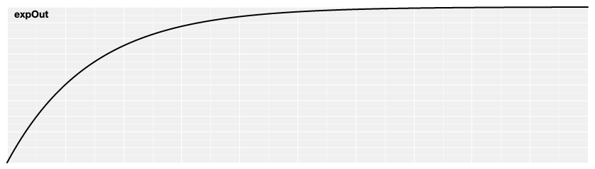

###### d3.**easeExp**(*t*) [Source](https://github.com/d3/d3-ease/blob/master/src/exp.js) d3.**easeExpInOut**(*t*) [Source](https://github.com/d3/d3-ease/blob/master/src/exp.js#L9)

Symmetric exponential easing; scales expIn for *t* in [0, 0.5] and expOut for *t* in [0.5, 1].

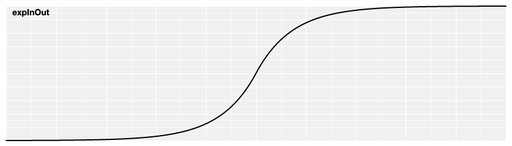

###### d3.**easeCircleIn**(*t*) [Source](https://github.com/d3/d3-ease/blob/master/src/circle.js#L1)

Circular easing.

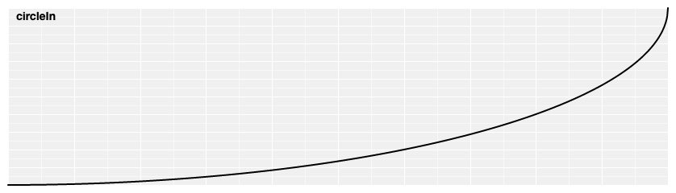

###### d3.**easeCircleOut**(*t*) [Source](https://github.com/d3/d3-ease/blob/master/src/circle.js#L5)

Reverse circular easing; equivalent to 1 - circleIn(1 - *t*).

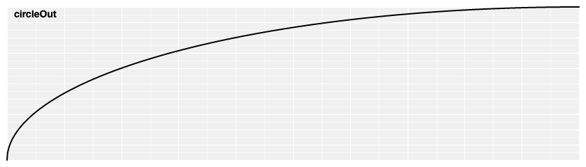

###### d3.**easeCircle**(*t*) [Source](https://github.com/d3/d3-ease/blob/master/src/circle.js) d3.**easeCircleInOut**(*t*) [Source](https://github.com/d3/d3-ease/blob/master/src/circle.js#L9)

Symmetric circular easing; scales circleIn for *t* in [0, 0.5] and circleOut for *t* in [0.5, 1].

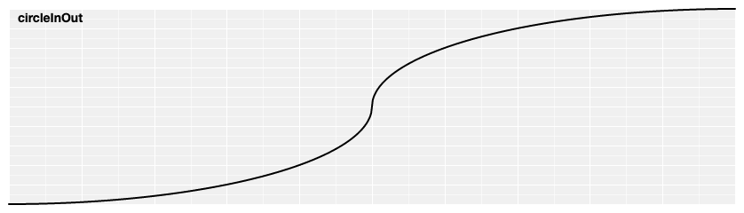

###### d3.**easeElasticIn**(*t*) [Source](https://github.com/d3/d3-ease/blob/master/src/elastic.js#L5)

Elastic easing, like a rubber band. The amplitude and period of the oscillation are configurable; if not specified, they default to 1 and 0.3, respectively.

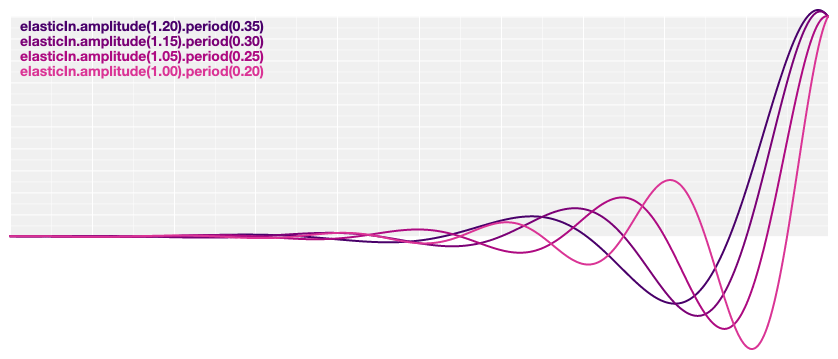

###### d3.**easeElastic**(*t*) [Source](https://github.com/d3/d3-ease/blob/master/src/elastic.js) d3.**easeElasticOut**(*t*) [Source](https://github.com/d3/d3-ease/blob/master/src/elastic.js#L18)

Reverse elastic easing; equivalent to 1 - elasticIn(1 - *t*).

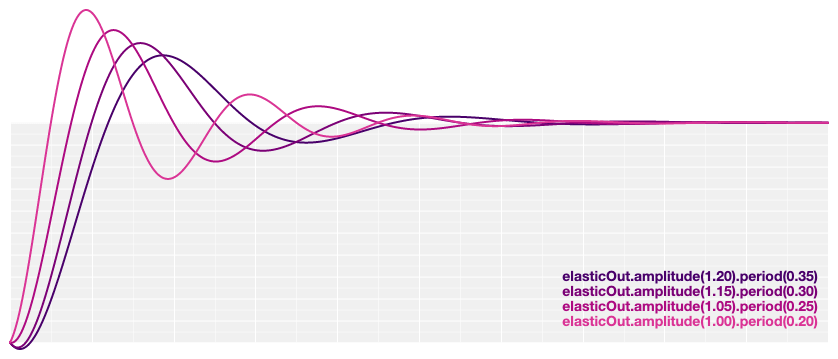

###### d3.**easeElasticInOut**(*t*) [Source](https://github.com/d3/d3-ease/blob/master/src/elastic.js#L31)

Symmetric elastic easing; scales elasticIn for *t* in [0, 0.5] and elasticOut for *t* in [0.5, 1].

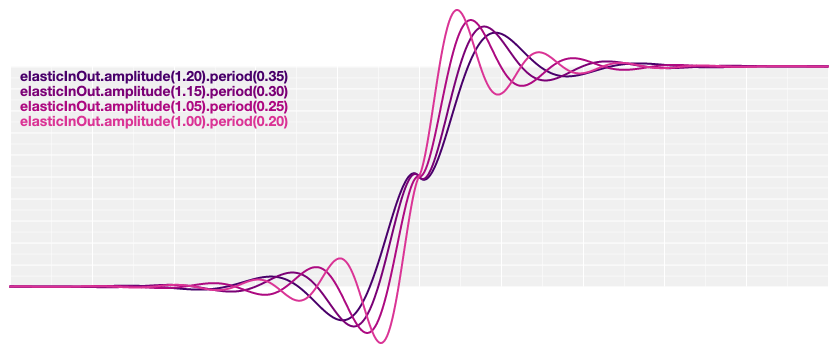

###### *elastic*.**amplitude**(*a*) [Source](https://github.com/d3/d3-ease/blob/master/src/elastic.js#L40)

Returns a new elastic easing with the specified amplitude *a*.

###### *elastic*.**period**(*p*) [Source](https://github.com/d3/d3-ease/blob/master/src/elastic.js#L41)

Returns a new elastic easing with the specified period *p*.

###### d3.**easeBackIn**(*t*) [Source](https://github.com/d3/d3-ease/blob/master/src/back.js#L3)

[Anticipatory](https://en.wikipedia.org/wiki/12_basic_principles_of_animation#Anticipation) easing, like a dancer bending his knees before jumping off the floor. The degree of overshoot is configurable; if not specified, it defaults to 1.70158.

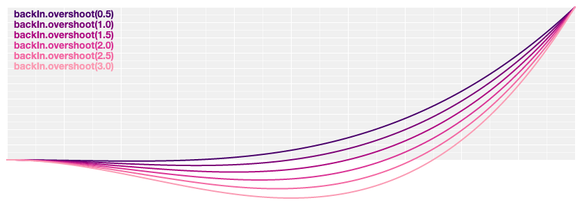

###### d3.**easeBackOut**(*t*) [Source](https://github.com/d3/d3-ease/blob/master/src/back.js#L15)

Reverse anticipatory easing; equivalent to 1 - backIn(1 - *t*).

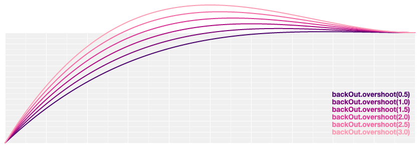

###### d3.**easeBack**(*t*) [Source](https://github.com/d3/d3-ease/blob/master/src/back.js) d3.**easeBackInOut**(*t*) [Source](https://github.com/d3/d3-ease/blob/master/src/back.js#L27)

Symmetric anticipatory easing; scales backIn for *t* in [0, 0.5] and backOut for *t* in [0.5, 1].

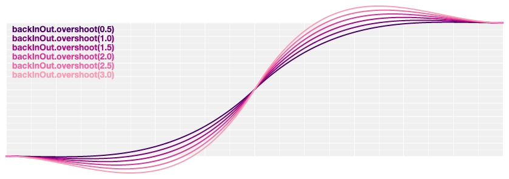

###### *back*.**overshoot**(*s*) [Source](https://github.com/d3/d3-ease/blob/master/src/back.js#L1)

Returns a new back easing with the specified overshoot *s*.

###### d3.**easeBounceIn**(*t*) [Source](https://github.com/d3/d3-ease/blob/master/src/bounce.js#L12)

Bounce easing, like a rubber ball.

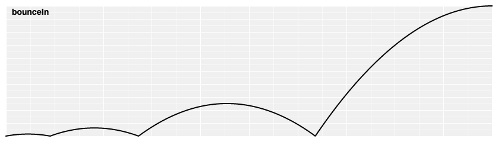

###### d3.**easeBounce**(*t*) [Source](https://github.com/d3/d3-ease/blob/master/src/bounce.js) d3.**easeBounceOut**(*t*) [Source](https://github.com/d3/d3-ease/blob/master/src/bounce.js#L16)

Reverse bounce easing; equivalent to 1 - bounceIn(1 - *t*).

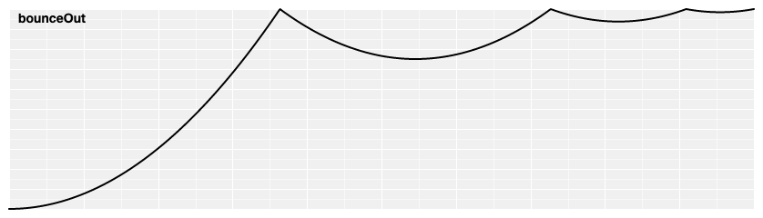

###### d3.**easeBounceInOut**(*t*) [Source](https://github.com/d3/d3-ease/blob/master/src/bounce.js#L20)

Symmetric bounce easing; scales bounceIn for *t* in [0, 0.5] and bounceOut for *t* in [0.5, 1].

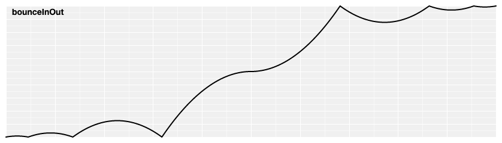

© 2010–2023 Michael Bostock  
Licensed under the BSD License.  
https://github.com/d3/d3-ease